# Visualization – Part 3. Asthma

Xuewei Zhang

## BST 260 Final Project

## Group: Chuying Ma, Jingjing Tang, Jie Yin, Xuewei Zhang

This Rmd file is for plotting asthma distribution by county level from 2000 to 2010, to see if there is any pattern in it.

### Part 1. Map for asthma disease in the county level from 2000 to 2010

```r
library(dplyr)
```

```r
library(ggplot2)
library(RColorBrewer)
asthma_data = read.csv("10_year_data.csv")

ash <- asthma_data %>%
  dplyr::select(fips,asthma,year)
cnty <- map_data("county")

names(asthma_data)
```

```
##  [1] "fips"         "state"        "county"       "year"
##  [5] "menthlth"     "heartattack"  "ACheartdis"   "stroke"
##  [9] "asthma"       "age"          "sex"          "white"
## [13] "black"        "asian"        "race_other"   "educ1"
## [17] "educ2"        "educ3"        "income1"      "income2"
## [21] "income3"      "income4"      "income5"      "income6"
## [25] "income7"      "income8"      "married"      "unmarried"
## [29] "employed"     "out_of_work"  "homemaker"    "student"
## [33] "employ_other" "hlthplan"     "exercise"     "smoke"
## [37] "drink"        "bmi_cat1"     "bmi_cat2"     "bmi_cat3"
## [41] "bmi_cts"      "genhlth_ex"   "genhlth_vg"   "genhlth_go"
## [45] "genhlth_fa"   "genhlth_po"   "qlactlm"
```

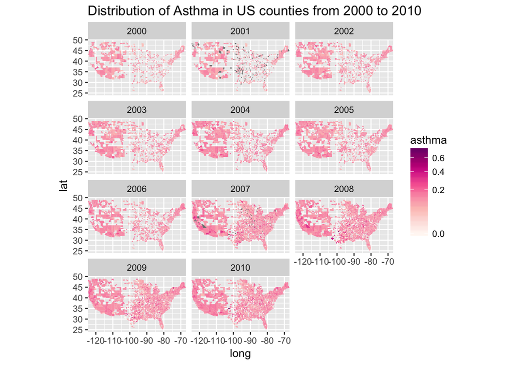

```r
men_map <- cnty %>%
  mutate(polyname = paste(region,subregion,sep=",")) %>%
  left_join(county.fips, by="polyname")

men_df <- inner_join(men_map, ash, by=c("fips" = "fips"))

map_all_year = ggplot(men_df, aes(long, lat,group = group)) +
  geom_polygon(aes(fill = asthma)) + coord_quickmap() +
  scale_x_continuous(expand=c(0,0)) +
  scale_fill_gradientn(colors = brewer.pal(8, "RdPu"), trans = "sqrt") +
  facet_wrap(~year,ncol = 3) +
  ggtitle("Distribution of Asthma in US counties from 2000 to 2010")
map_all_year
```

## Conclusion

From year 2000-2010, the distribution of asthma is geographically distinctive.

In general, people in the west part is more likely to catch asthma than people in east part. Due to some missing values in the middle part of United States, the states which have high probability of catching asthma are California, which has some obvious red spots.

### Part 2. Univariate analysis for income vs asthma:

```r
library(readr)
library(dplyr)
library(tidyverse)
library(broom)
library(dslabs)
ds_theme_set()
data_all = read_csv("data_exposure_00_10.csv")
```

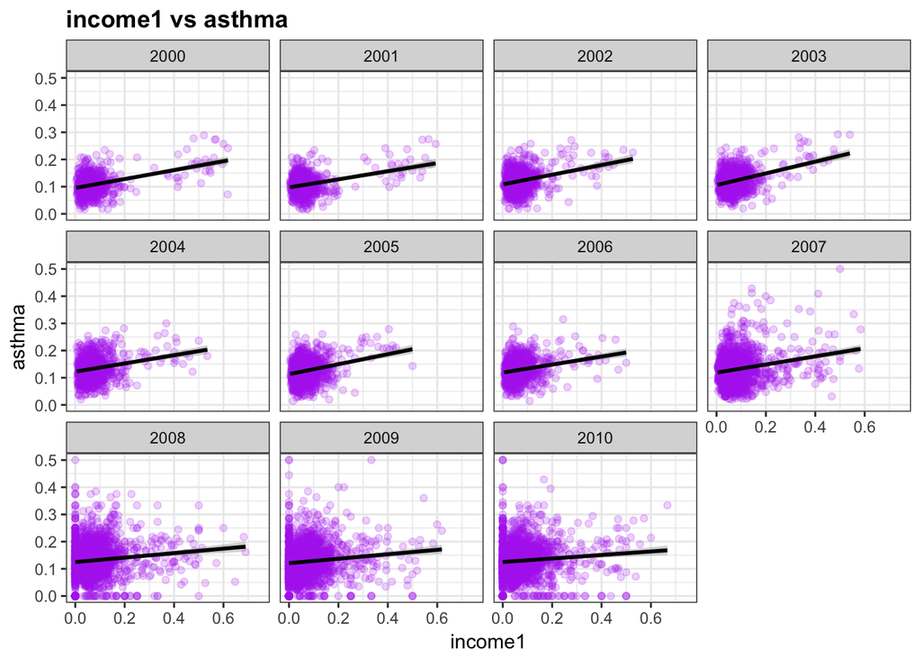

```r
group_as_fit = data_all %>%
  dplyr::select(-c(fips,state,county)) %>%
  ggplot(aes(income1,asthma)) +
  geom_point(alpha = 0.2,col = "darkorchid2") +
  geom_smooth(method = "lm",col = "black") +
  facet_wrap(~ year) +
  ggtitle("income1 vs asthma") +
  xlim(0,0.75) +
  ylim(0,0.5)
group_as_fit
```

## Conclusion

If more people in the ‘income1’ category, there are more asthma diseases, which means people who are poor are more likely to have asthma